# Markdown

## Presentations

[figure not shown]

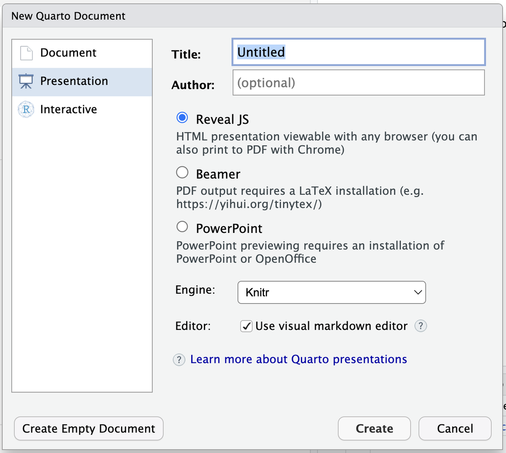

## Presentation Formats (Visual)

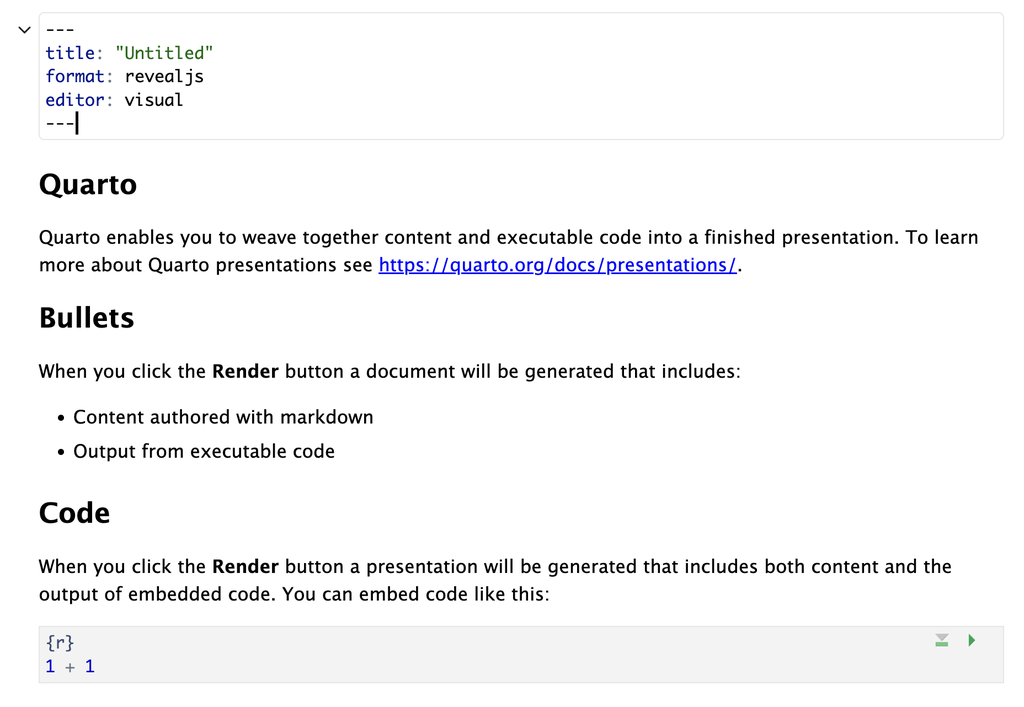

## Presentation Formats (Source)

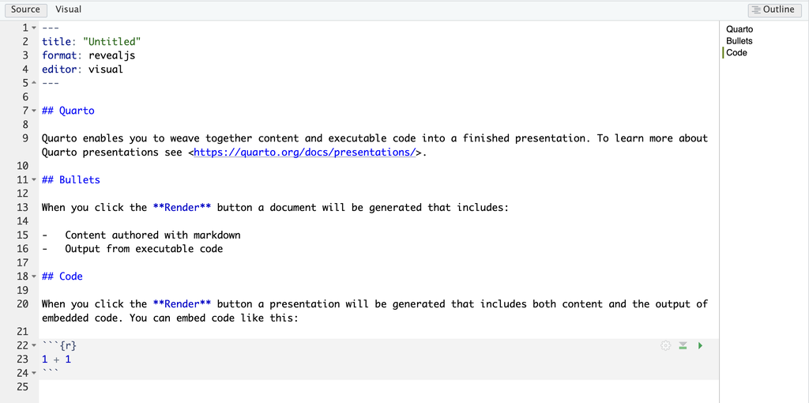

## Slide Separation

### Formatting Individual Slide Content

- Each slice starts with a **H2** (e.g., `## title`), which is denoted as its “Slide Title”,
- Subtitles are **H3** (`### subtitle`),
- Remaining content is normal markdown.

## Customizations

There are a `ton` of customizations available. I would suggest you look to the official [Quarto Reference](https://quarto.org/docs/reference/) site:

[figure not shown]

## Questions

If you have any questions, please feel free to either post to the [Canvas](https://canvas.vcu.edu) discussion board for the class or drop me an email.

[figure not shown]